# Ocean Acidification

# Discussion 2

In the plot we can see fluctuations on the surface pH concentration on the same year, this changes can be attributed to seasonal changes at BATS. During winter months the pH is lower and it increases in the summer. The model interpretation shows that pH decrease with time base on the linear regression and ANOVA (shows variability).Where the p-value was 2.2e-16 there is an annual decrease of -1.793e-03 pH on surface ocean. This could be attributed to ocean acidification due to climate change.

**3) Is surface ocean seawater saturation state with respect to aragonite decreasing?**

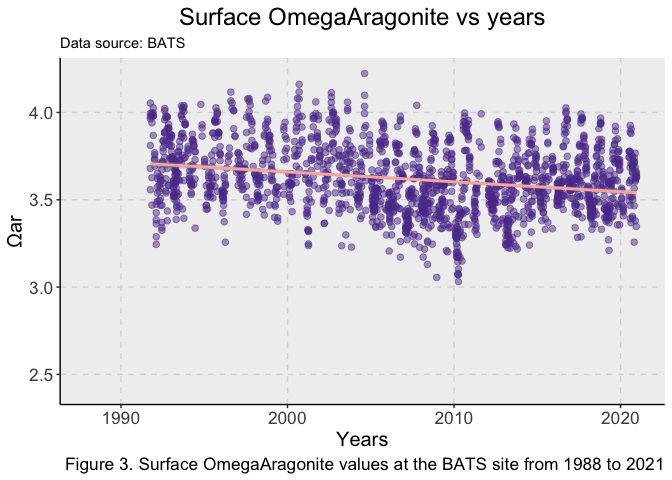

```r
bats_co2sys_surf %>%
  ggplot(mapping=aes(x=decy,y=OmegaAragonite)) +
  geom_point(color="#5e3c99",size = 2,alpha=0.5) +
  geom_smooth(method="lm",size=1.0,color="#fbb4ae") +
  scale_x_continuous(limits = c(1988,2021))+
  labs(x="Years",y="Ωar",title="Surface OmegaAragonite vs years",
       subtitle="Data source: BATS")+
  theme_classic()+
  theme(plot.title=element_text(hjust=0.5,size=18),
        axis.title=element_text(size=15),
        axis.text=element_text(size=13),
        plot.caption=element_text(size=13))+
  theme(panel.grid.major=element_line(color="#d9d9d9",linetype="dashed"),
        panel.grid.minor=element_blank(),
        panel.background=element_rect(fill="#f0f0f0"))+
  labs(caption="Figure 3. Surface OmegaAragonite values at the BATS site from 1988 to 2021")
```

```r
OmegaAragonite_model=lm(OmegaAragonite~decy,data=bats_co2sys_surf)
#Linear regression between surface pCO2 and the years
```

**Checking model performance**

```r
#This is used to confirm assumptions about the model
#check_model(pH_model)

#The summary is using ANOVA to produce the p-values.
summary(OmegaAragonite_model) #the summary of the lineal regression
```

```
##
## Call:
## lm(formula = OmegaAragonite ~ decy, data = bats_co2sys_surf)
##
## Residuals:
##     Min      1Q  Median      3Q     Max
## -1.1169 -0.1339 -0.0160  0.1348  0.5904
##
## Coefficients:
##               Estimate Std. Error t value Pr(>|t|)
## (Intercept) 15.3223685  0.9807773   15.62   <2e-16 ***
## decy        -0.0058313  0.0004885  -11.94   <2e-16 ***
## ---
## Signif. codes:  0 '***' 0.001 '**' 0.01 '*' 0.05 '.' 0.1 ' ' 1
##
## Residual standard error: 0.1901 on 1937 degrees of freedom
## Multiple R-squared:  0.06853,    Adjusted R-squared:  0.06805
## F-statistic: 142.5 on 1 and 1937 DF,  p-value: < 2.2e-16
```

```r
anova(OmegaAragonite_model)
```

```
## Analysis of Variance Table
##
## Response: OmegaAragonite
##             Df Sum Sq Mean Sq F value    Pr(>F)
## decy         1  5.149  5.1489  142.51 < 2.2e-16 ***
## Residuals 1937 69.984  0.0361
## ---
## Signif. codes:  0 '***' 0.001 '**' 0.01 '*' 0.05 '.' 0.1 ' ' 1
```

**Ploting model prediction**

We use this to confirm that our previews data is correct

```r
#Using R method
bats_co2sys_surf_pred=
  cbind(bats_co2sys_surf, predict(OmegaAragonite_model, interval = 'confidence',level=0.95))

#Adding the prediction line of OmegaAragonite_model to ggplot
#This predictions could be used to merge the bats_co2sys_surf with the bats_co2sys_surf_pred. We can make with this a two variable plot with the prediction model giving a shaded region of 95% of confidence around the model line.
```

# Discussion 3

In the plot we can see fluctuations on the surface OmegaAragonite concentration on the same year, this changes can be attributed to seasonal changes at BATS. During winter months the OmegaAragonite is lower and it increases in the summer. The model interpretation shows that OmegaAragonite decrease with time base on the linear regression and ANOVA (shows variability).Where the p-value is 2.2e-16 there is an annual decrease of -0.0058313 OmegaAragonite on surface ocean. It can be associated with the same decrease in pH which decrease the ability of calcium carbonate organism to regenerate or form their shells or skeletons.This could be attributed to ocean acidification due to climate change.